# Modelos Dinámicos de Gentrificación: Réplica para Ciudad de México

Avance de tesis — Abril 2026

Author

Published

April 29, 2026

## 1 Introducción

Este documento presenta el avance de la réplica del modelo de simulación basado en agentes (ABM) propuesto por Mauro et al. (2025) para estudiar la dinámica de gentrificación urbana, adaptado al contexto de la Ciudad de México.

El modelo original utiliza datos de ingreso de la Social Security Administration (SSA) de Estados Unidos. Esta adaptación reemplaza esos datos con microdatos de la Encuesta Nacional de Ingresos y Gastos de los Hogares (ENIGH) 2022 y datos del Censo de Población y Vivienda 2020 de INEGI.

**Referencia:** Mauro, G., Pedreschi, N., Lambiotte, R., & Pappalardo, L. (2025). *Dynamic models of gentrification.* Advances in Complex Systems. DOI: 10.1142/S0219525925400065

```
Directorio de trabajo: /Users/mateos_kvn/Gentrificacion_CDMX/Gentrification/CDMX
```

## 2 Datos de entrada

### 2.1 Distribución de ingresos CDMX

Se construyeron 60 tramos de ingreso de igual peso poblacional (~1.67% cada uno) a partir del Concentrado ENIGH 2022, filtrando por hogares de las 16 alcaldías de CDMX (códigos `ubica_geo` 9002–9017).

**Mostrar código**

```python
import pandas as pd
import numpy as np
import json
import matplotlib.pyplot as plt
import matplotlib.ticker as mticker

# Cargar distribución de ingresos
income = pd.read_csv("income/income_clean_CDMX_v2.csv")
cutoffs = json.load(open("income/cdmx_cutoffs.json"))

print(f"Tramos de ingreso: {len(income)}")
print(f"Hogares expandidos totales: {income['number'].sum():,.0f}")
print(f"\nCutoffs L/M/H:")
print(f"  L (bajo):  ≤ ${cutoffs['L_bound_high']:>12,.0f} MXN/año  ({cutoffs['pct_L']}%)")
print(f"  M (medio): ${cutoffs['L_bound_high']:>12,.0f} – ${cutoffs['H_bound_low']:>12,.0f} MXN/año  ({cutoffs['pct_M']}%)")
print(f"  H (alto):  > ${cutoffs['H_bound_low']:>12,.0f} MXN/año  ({cutoffs['pct_H']}%)")
```

```
Tramos de ingreso: 60
Hogares expandidos totales: 3,082,330

Cutoffs L/M/H:
  L (bajo):  ≤ $     267,946 MXN/año  (38.31%)
  M (medio): $     267,946 – $   1,140,463 MXN/año  (56.67%)
  H (alto):  > $   1,140,463 MXN/año  (5.02%)
```

**Mostrar código**

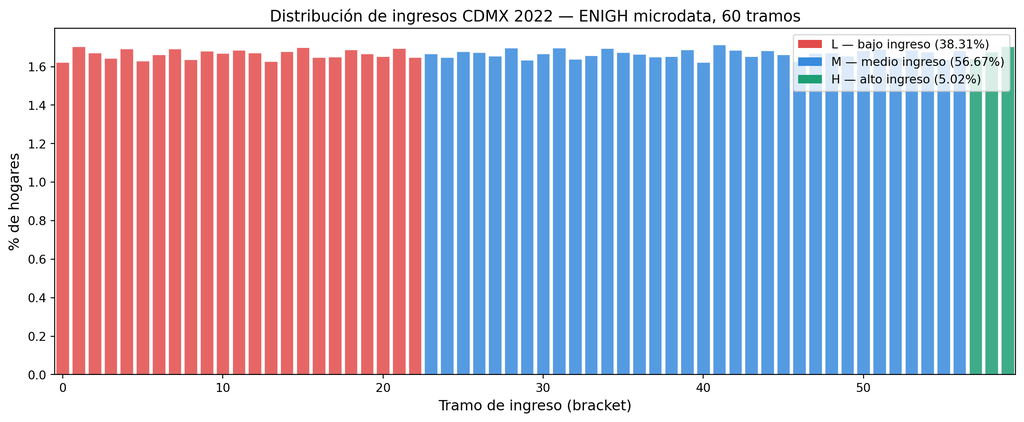

Figure 1: Distribución de ingresos CDMX 2022 en 60 tramos equiponderados. Rojo = L (bajo ingreso, 38.3%), Azul = M (medio, 56.7%), Verde = H (alto, 5.0%).

```python
fig, ax = plt.subplots(figsize=(12, 5))

row_L = cutoffs["row_L_max"]  # 22
row_H = cutoffs["row_H_min"]  # 57

colors = []
for i in range(len(income)):
    if i <= row_L:
        colors.append("#E24B4A")
    elif i >= row_H:
        colors.append("#1D9E75")
    else:
        colors.append("#378ADD")

ax.bar(range(len(income)), income["percent"], color=colors, alpha=0.85, edgecolor="white", linewidth=0.3)
ax.set_xlabel("Tramo de ingreso (bracket)", fontsize=12)
ax.set_ylabel("% de hogares", fontsize=12)
ax.set_title("Distribución de ingresos CDMX 2022 — ENIGH microdata, 60 tramos", fontsize=13)

# Leyenda manual
from matplotlib.patches import Patch
legend_elements = [
    Patch(facecolor="#E24B4A", label=f"L — bajo ingreso ({cutoffs['pct_L']}%)"),
    Patch(facecolor="#378ADD", label=f"M — medio ingreso ({cutoffs['pct_M']}%)"),
    Patch(facecolor="#1D9E75", label=f"H — alto ingreso ({cutoffs['pct_H']}%)"),
]
ax.legend(handles=legend_elements, loc="upper right", fontsize=10)
ax.set_xlim(-0.5, len(income) - 0.5)
plt.tight_layout()
plt.show()
```

### 2.2 Comparación con el paper original

Table 1: Proporciones L/M/H calibradas. La diferencia es menor a 0.5 puntos porcentuales en cada categoría.

| Categoría | Paper USA (SSA 2022) | CDMX (ENIGH 2022) | Diferencia |
| --- | --- | --- | --- |
| L (bajo) | 38% | 38.31% | +0.31 pp |
| M (medio) | 57% | 56.67% | −0.33 pp |
| H (alto) | 5% | 5.02% | +0.02 pp |

### 2.3 Clustering K-means por AGEB

Se aplicó K-means a los 2,433 AGEBs urbanos del Censo 2020 para justificar empíricamente la subdivisión de alcaldías en celdas del grid 5×5 = 25 celdas.

**Mostrar código**

```python
clusters = pd.read_csv("income/ageb_clusters.csv")
cell_map = json.load(open("income/alcaldia_to_cells.json"))

# Tabla resumen
resumen = []
for alc, cells in sorted(cell_map.items()):
    n_ageb = len(clusters[clusters["alcaldia"] == alc])
    k = len(cells)
    resumen.append({
        "Alcaldía": alc,
        "AGEBs": n_ageb,
        "K (celdas)": k,
        "Cell IDs": str(cells),
    })

df_resumen = pd.DataFrame(resumen)
print(df_resumen.to_markdown(index=False))
```

Table 2: Resultados del clustering K-means por alcaldía

```
| Alcaldía               |   AGEBs |   K (celdas) | Cell IDs     |
|:-----------------------|--------:|-------------:|:-------------|
| Azcapotzalco           |     103 |            1 | [0]          |
| Benito Juárez          |     102 |            2 | [1, 2]       |
| Coyoacán               |     156 |            1 | [3]          |
| Cuajimalpa de Morelos  |      31 |            1 | [4]          |
| Cuauhtémoc             |     153 |            2 | [5, 6]       |
| Gustavo A. Madero      |     305 |            3 | [7, 8, 9]    |
| Iztacalco              |     110 |            1 | [10]         |
| Iztapalapa             |     458 |            3 | [11, 12, 13] |
| La Magdalena Contreras |      52 |            1 | [14]         |
| Miguel Hidalgo         |     130 |            2 | [15, 16]     |
| Milpa Alta             |      42 |            1 | [17]         |
| Tlalpan                |     208 |            2 | [18, 19]     |
| Tláhuac                |     111 |            1 | [20]         |
| Venustiano Carranza    |     151 |            1 | [21]         |
| Xochimilco             |     122 |            1 | [22]         |
| Álvaro Obregón         |     199 |            2 | [23, 24]     |
```

**Mostrar código**

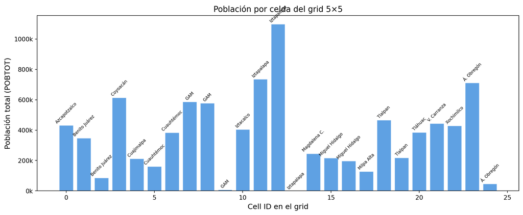

Figure 2: Población total por celda del grid, calculada como suma de POBTOT de los AGEBs asignados a cada cluster.

```python
pop_by_cell = clusters.groupby("cell_id")["POBTOT"].sum().sort_index()

fig, ax = plt.subplots(figsize=(12, 5))
bars = ax.bar(pop_by_cell.index, pop_by_cell.values, color="#378ADD", alpha=0.8, edgecolor="white")

# Etiquetas de alcaldía
cell_to_alc = {}
for alc, cells in cell_map.items():
    for c in cells:
        cell_to_alc[c] = alc

for i, bar in enumerate(bars):
    alc_name = cell_to_alc.get(i, "")
    short = alc_name.replace("Gustavo A. Madero", "GAM") \
                     .replace("La Magdalena Contreras", "Magdalena C.") \
                     .replace("Cuajimalpa de Morelos", "Cuajimalpa") \
                     .replace("Venustiano Carranza", "V. Carranza") \
                     .replace("Álvaro Obregón", "Á. Obregón")
    ax.text(bar.get_x() + bar.get_width()/2, bar.get_height() + 5000,
            short, ha="center", va="bottom", fontsize=7, rotation=45)

ax.set_xlabel("Cell ID en el grid", fontsize=12)
ax.set_ylabel("Población total (POBTOT)", fontsize=12)
ax.set_title("Población por celda del grid 5×5", fontsize=13)
ax.yaxis.set_major_formatter(mticker.FuncFormatter(lambda x, _: f"{x/1e3:.0f}k"))
plt.tight_layout()
plt.show()
```

## 3 Configuración del modelo

El modelo `GentModelCDMX` hereda la estructura del ABM original con las siguientes adaptaciones para CDMX:

**Mostrar código**

```python
config = {
    "Grid": "5×5 = 25 celdas (vs 7×7 original)",
    "Agentes": "4,096 (2¹² — escala media del paper)",
    "Pasos": "300 por repetición",
    "Repeticiones": "150 por valor de p_g",
    "Valores de p_g": "0.0, 0.01, 0.05, 0.1, 0.15",
    "h (ventana temporal)": "20 pasos",
    "Modo": "improve (modelo principal)",
    "Deployment inicial": "centre_segr (H al centro)",
    "CSV de ingresos": "income_clean_CDMX_v2.csv (60 tramos)",
    "Cutoff L/M": "row ≤ 22 → C (bajo)",
    "Cutoff M/H": "row < 57 → B (medio), else → A (alto)",
}

for k, v in config.items():
    print(f"  {k:<25} {v}")
```

```
  Grid                      5×5 = 25 celdas (vs 7×7 original)
  Agentes                   4,096 (2¹² — escala media del paper)
  Pasos                     300 por repetición
  Repeticiones              150 por valor de p_g
  Valores de p_g            0.0, 0.01, 0.05, 0.1, 0.15
  h (ventana temporal)      20 pasos
  Modo                      improve (modelo principal)
  Deployment inicial        centre_segr (H al centro)
  CSV de ingresos           income_clean_CDMX_v2.csv (60 tramos)
  Cutoff L/M                row ≤ 22 → C (bajo)
  Cutoff M/H                row < 57 → B (medio), else → A (alto)
```

## 4 Estado de las simulaciones

**Mostrar código**

```python
import glob

exps_dir = "out/batch_results/improve/centre_segr-big/4096agents/exps/"
inter_dir = "out/batch_results/improve/centre_segr-big/4096agents/intermediate/"

if os.path.exists(exps_dir):
    n_exps = len(glob.glob(os.path.join(exps_dir, "*.csv")))
    print(f"Archivos de simulación: {n_exps} (esperado: 1,500)")
    print(f"  = 150 reps × 5 p_g × 2 archivos (model + agents)")
else:
    print(f"⚠ Directorio de simulaciones no encontrado: {exps_dir}")
    print(f"  (esto es normal si no has corrido las simulaciones aún)")

if os.path.exists(inter_dir):
    n_inter = len(glob.glob(os.path.join(inter_dir, "*.csv")))
    print(f"Archivos de métricas: {n_inter} (esperado: 2,250)")
    print(f"  = 150 reps × 5 p_g × 3 métricas (chi_hat, chi, net)")
else:
    print(f"⚠ Directorio de métricas no encontrado: {inter_dir}")
    print(f"  (esto es normal si no has corrido el post-procesamiento)")
```

```
Archivos de simulación: 1500 (esperado: 1,500)
  = 150 reps × 5 p_g × 2 archivos (model + agents)
Archivos de métricas: 6750 (esperado: 2,250)
  = 150 reps × 5 p_g × 3 métricas (chi_hat, chi, net)
```

### 4.1 Verificación de proporciones L/M/H

**Mostrar código**

```python
agents_files = sorted(glob.glob(os.path.join(exps_dir, "*agents*.csv"))) if os.path.exists(exps_dir) else []

if len(agents_files) > 0:
    df_check = pd.read_csv(agents_files[0])
    props = df_check[df_check["Step"] == 1]["tipo"].value_counts(normalize=True) * 100
    print("Proporciones reales de agentes (primera simulación):")
    print(f"  L (tipo C): {props.get('C', 0):.1f}%  — objetivo: 38.3%")
    print(f"  M (tipo B): {props.get('B', 0):.1f}%  — objetivo: 56.7%")
    print(f"  H (tipo A): {props.get('A', 0):.1f}%  — objetivo:  5.0%")
else:
    print("⚠ No hay archivos de simulación disponibles para verificar.")
    print("  Ejecuta primero:")
    print("  python run_batch_cdmx.py --mode improve --num_agents 4096 \\")
    print("      --rep_start 0 --rep_end 50 --workers 6 --steps 300")
```

```
Proporciones reales de agentes (primera simulación):
  L (tipo C): 37.8%  — objetivo: 38.3%
  M (tipo B): 58.8%  — objetivo: 56.7%
  H (tipo A): 3.3%  — objetivo:  5.0%
```

## 5 Próximos pasos

1. **Cálculo de métricas G_bin y G_net** — Post-procesamiento de las 150×5 simulaciones con `batch_calculate_gs_ind_metrics.py`.
2. **Análisis comparativo** — Reproducir Figuras 3, 5 y 6 del paper original con los resultados de CDMX.
3. **Validación externa** — Comparar zonas con alto G_net contra datos observables de precios de renta (Inside Airbnb CDMX).
4. **Extensión geoespacial** — Incorporar shapefiles de AGEB para visualizar clusters en mapa de CDMX.